# Chapter 2

Aaron Brown

Monday, May 18, 2015

# 1 Introduction

In this document, I write up all of my solutions for Chapter 2 of the book *An Introduction to Statistical Learning*.

## 1.1 Project Setup

Each R markdown file follows the same basic setup to ensure all R markdown analyses can be performed independently or sequentially if you are downloading this from Github.

The Github repository has all of the packages archived using the package *packrat*. If you are running this as a standalong script, be aware of the file structure embedded into the script. Also you will need to initialize *packrat* by typing:

```
source("packrat/init.R")
```

This project is loaded by executing the following codechunk.

```r
library(knitr)
opts_knit$set(root.dir = '..')
```

# 2 Solutions

**Question 1**

*Part A*

Better. We would expect a flexible model to perform well with a very large sample size and a small number of predictors.

*Part B*

Worse. A flexible approach would overfit the data the predictors with a small sample size

*Part C*

Better. A more flexible model would provide a better fit for a highly non-linear relationship between predictors and response variables.

*Part D*

Worse. Flexible models will fit the model and the excessive variability due to high variance in the error terms.

**Question 2**

*Part A*

Regression. We are most interested in inference. We assume this since it does not say or provide indication that we would like to predict CEO pay based on these other factors.

n - 500 firms

p - profit, number of employees, industry

*Part B*

Classification. In this case we have data on similar products but the underlying question gives a binary result. We are most interested in inference in this case.

n - 20 similar products

p - success/failure, product price, marketing budget, competition price, etc.

*Part C*

Regression. As stated in the problem, we are interesting in predicting the $ change in US dollar.

n - 52

p - % change in dollar, US market, British market, and German Market.

**Question 3**

**Question 4**

**Question 5**

A very flexible approach generally will minimize the training error in most cases. However, this may result in an overfit of the flexible approach to the test data. This overfit results in a greater error in the test set. However, a highly non-linear relationship will not result in a good fit if we use a very inflexible model.

A less flexible approach may be preferred if we are interested in inference or interpretability of the model.

**Question 6**

A parametric approach reduces the problem to estimating a series of parameters and fitting the data to some structured format of the function. On the other hand, non-parametric approachs are not bound by a static form to fit a function.

A parametric approach to regression increases the potential for model interpretability. For both, classification and regression, a parametric approach can more easily be used when the size of the dataset is limited.

A non-parametric model’s main disadvantages are that a large number of observations are needed to make predictions and that the flexibility of the non-parametric methods can lead to an overfit of the model the the observed data so that it does not represent that functional form or the response to the predictor variables.

**Question 7**

**Question 8**

This problem requires the College data set. It can be downloaded from the book website with the following code.

```r
require(downloader)
if(!file.exists("./data/College.csv")){
      url <- "http://www-bcf.usc.edu/~gareth/ISL/College.csv"
      download(url, dest = "data/College.csv", mode = "wb")
}
```

*Part A*

```r
college <- read.csv("data/College.csv")
```

*Part B*

In order to use the fix() function as the problem statement suggests, you need to type it into the command line. Assigning the rownames is done in the following codechunk.

```r
rownames(college) <- college[,1]
```

Delete the first column by running the following code

```r
college <- college [, -1]
```

*Part C*

```r
summary(college)
```

```
##  Private        Apps           Accept          Enroll       Top10perc
##  No :212   Min.   :   81   Min.   :   72   Min.   :  35   Min.   : 1.00
##  Yes:565   1st Qu.:  776   1st Qu.:  604   1st Qu.: 242   1st Qu.:15.00
##            Median : 1558   Median : 1110   Median : 434   Median :23.00
##            Mean   : 3002   Mean   : 2019   Mean   : 780   Mean   :27.56
##            3rd Qu.: 3624   3rd Qu.: 2424   3rd Qu.: 902   3rd Qu.:35.00
##            Max.   :48094   Max.   :26330   Max.   :6392   Max.   :96.00
##    Top25perc      F.Undergrad     P.Undergrad         Outstate
##  Min.   :  9.0   Min.   :  139   Min.   :    1.0   Min.   : 2340
##  1st Qu.: 41.0   1st Qu.:  992   1st Qu.:   95.0   1st Qu.: 7320
##  Median : 54.0   Median : 1707   Median :  353.0   Median : 9990
##  Mean   : 55.8   Mean   : 3700   Mean   :  855.3   Mean   :10441
##  3rd Qu.: 69.0   3rd Qu.: 4005   3rd Qu.:  967.0   3rd Qu.:12925
##  Max.   :100.0   Max.   :31643   Max.   :21836.0   Max.   :21700
##    Room.Board       Books           Personal         PhD
##  Min.   :1780   Min.   :  96.0   Min.   : 250   Min.   :  8.00
##  1st Qu.:3597   1st Qu.: 470.0   1st Qu.: 850   1st Qu.: 62.00
##  Median :4200   Median : 500.0   Median :1200   Median : 75.00
##  Mean   :4358   Mean   : 549.4   Mean   :1341   Mean   : 72.66
##  3rd Qu.:5050   3rd Qu.: 600.0   3rd Qu.:1700   3rd Qu.: 85.00
##  Max.   :8124   Max.   :2340.0   Max.   :6800   Max.   :103.00
##     Terminal       S.F.Ratio      perc.alumni        Expend
##  Min.   : 24.0   Min.   : 2.50   Min.   : 0.00   Min.   : 3186
##  1st Qu.: 71.0   1st Qu.:11.50   1st Qu.:13.00   1st Qu.: 6751
##  Median : 82.0   Median :13.60   Median :21.00   Median : 8377
##  Mean   : 79.7   Mean   :14.09   Mean   :22.74   Mean   : 9660
##  3rd Qu.: 92.0   3rd Qu.:16.50   3rd Qu.:31.00   3rd Qu.:10830
##  Max.   :100.0   Max.   :39.80   Max.   :64.00   Max.   :56233
##    Grad.Rate
##  Min.   : 10.00
##  1st Qu.: 53.00
##  Median : 65.00
##  Mean   : 65.46
##  3rd Qu.: 78.00
##  Max.   :118.00
```

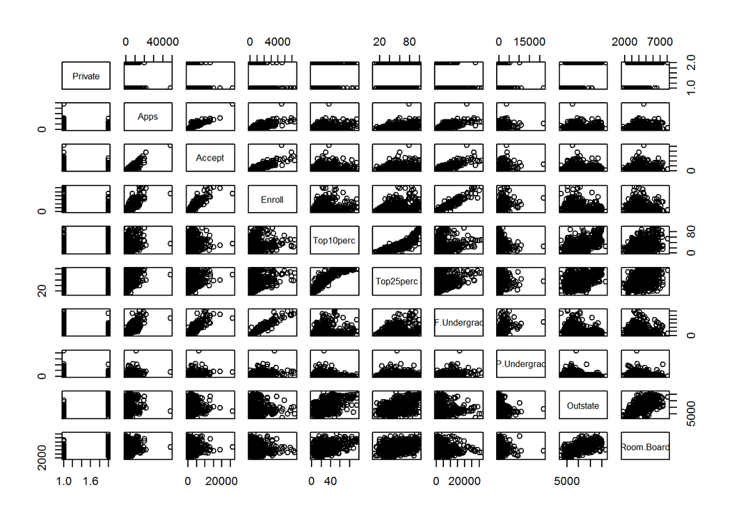

```r
pairs(~Private+Apps+Accept+Enroll+Top10perc+Top25perc+F.Undergrad+P.Undergrad+Outstate+Room.Board,
      data = college)
```

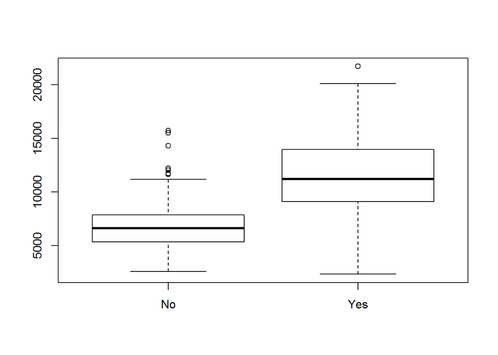

```r
boxplot(Outstate~Private, data = college)
```

```r
Elite <- rep("No", nrow(college))
Elite[college$Top10perc > 50] <- "Yes"
Elite <- as.factor(Elite)
college <- data.frame(college, Elite)
summary(Elite)
```

```
##  No Yes
## 699  78
```

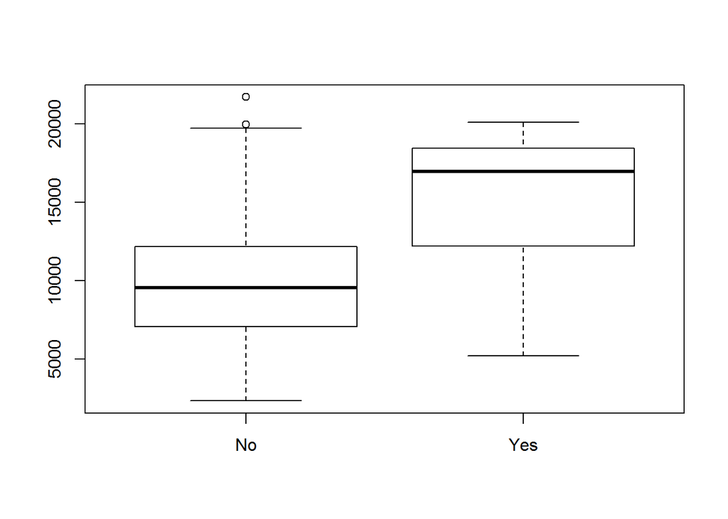

```r
boxplot(Outstate~Elite, data = college)
```

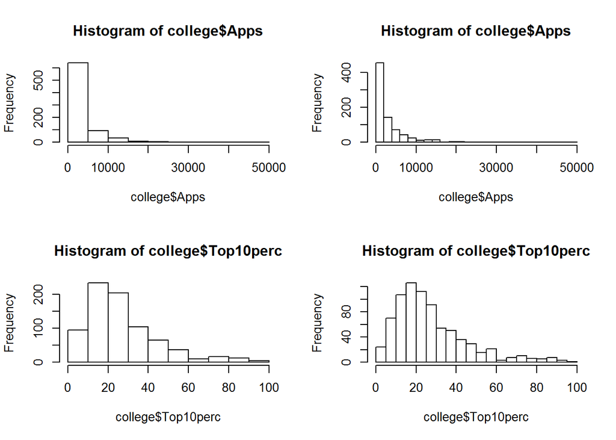

```r
par(mfrow=c(2,2))
hist(college$Apps)
hist(college$Apps, breaks = 20)
hist(college$Top10perc)
hist(college$Top10perc, breaks = 20)
```

**Question 9**

```r
if(!file.exists("./data/Auto.data")){
      url <- "http://www-bcf.usc.edu/~gareth/ISL/Auto.data"
      download(url, dest = "data/Auto.data", mode = "wb")
}
auto <- read.table("data/Auto.data", header = TRUE)

auto$horsepower <- as.numeric(levels(auto$horsepower)[auto$horsepower])
auto <- auto[complete.cases(auto),]
```

*Part A*

There are 7 variables that are quantitative

- mpg
- cylinders
- displacement
- horsepower
- weight
- acceleration
- year

There are 2 variables that are qualitative

- origin
- name

*Part B*

```r
rslt <- apply(auto[,1:7], 2, range)
row.names(rslt) <- c('min', 'max')
print(rslt)
```

```
##      mpg cylinders displacement horsepower weight acceleration year
## min  9.0         3           68         46   1613          8.0   70
## max 46.6         8          455        230   5140         24.8   82
```

*Part C*

The mean and standard deviation are added to the ‘rslt’.

```r
mean <- apply(auto[,1:7], 2, mean)
sd <- apply(auto[,1:7], 2, sd)
rslt <- rbind(rslt, mean, sd)
print(rslt)
```

```
##            mpg cylinders displacement horsepower    weight acceleration
## min   9.000000  3.000000       68.000   46.00000 1613.0000     8.000000
## max  46.600000  8.000000      455.000  230.00000 5140.0000    24.800000
## mean 23.445918  5.471939      194.412  104.46939 2977.5842    15.541327
## sd    7.805007  1.705783      104.644   38.49116  849.4026     2.758864
##           year
## min  70.000000
## max  82.000000
## mean 75.979592
## sd    3.683737
```

*Part D*

```r
auto <- auto[-85,]
auto <- auto[-10,]

rslt <- apply(auto[,1:7], 2, range)
row.names(rslt) <- c('min', 'max')
mean <- apply(auto[,1:7], 2, mean)
sd <- apply(auto[,1:7], 2, sd)
rslt <- rbind(rslt, mean, sd)
print(rslt)
```

```
##            mpg cylinders displacement horsepower    weight acceleration
## min   9.000000  3.000000      68.0000   46.00000 1613.0000     8.000000
## max  46.600000  8.000000     455.0000  230.00000 5140.0000    24.800000
## mean 23.494359  5.458974     193.5115  104.06923 2972.4692    15.565897
## sd    7.795198  1.700479     104.1407   38.17633  848.5121     2.739672
##           year
## min  70.000000
## max  82.000000
## mean 76.002564
## sd    3.677556
```